# Sentiment Analysis of Game of Thrones by G.R.R. Martin

Marius Henningsen, Malte Volquartzen And Soroosh Sabri

26 maj 2026, 18:32

First we load the packages we will use for the analysis including packages for text mining and visualisation

### We get the Game of Thrones pdf from the data folder:

```r
GOT_path <- here("data","GOT.pdf")
GOT_path
```

```
## [1] "C:/Users/Marius/OneDrive - IT Center Fyn/Documents/Historie BA/2. semester/DAM/R/DM1/SentimentAnalysis-main/SentimentAnalysis-main/data/GOT.pdf"
```

```r
# We make sure the text is recognized as an pdf text in R and look up a single random page to see if it loaded correctly.
GOT_text <- pdf_text(GOT_path)
# We choose to look up page 9
GOT_p9 <- GOT_text[9]
GOT_p9
```

```
## [1] "one before, when I was half a boy. Everyone talks about snows forty foot deep, and how\nthe ice wind comes howling out of the north, but the real enemy is the cold. It steals up\non you quieter than Will, and at first you shiver and your teeth chatter and you stamp\nyour feet and dream of mu…
```

The “pdf_text()” command returns a vector of strings, one for each page of the pdf. We turn it into a dataframe so we can mess with it in tidyverse style and keep track of the pages. We use stringr::str_split() to break the pages up into individual lines. Each line of the pdf is concluded with a backslash-n, so we split on this. We will also add a line number in addition to the page number.”

### Some wrangling:

- First We will split up pages into separate lines (separated by `\n`) using `stringr::str_split()`
- Second We will Unnest into regular columns using `tidyr::unnest()`
- Then We will remove leading/trailing white space with `stringr::str_trim()`

```r
# We split pages into separate lines

GOT_df <- data.frame(GOT_text) %>%
  mutate(text_full = str_split(GOT_text, pattern = '\n')) %>%
  unnest(text_full) %>%
  mutate(text_full = str_trim(text_full))

GOT_df
```

```
## # A tibble: 30,233 × 2
##    GOT_text                                                            text_full
##    <chr>                                                               <chr>
##  1 ""                                                                  ""
##  2 "                  A GAME OF THRONES\n\n\n            Book One of … "A GAME …
##  3 "                  A GAME OF THRONES\n\n\n            Book One of … ""
##  4 "                  A GAME OF THRONES\n\n\n            Book One of … ""
##  5 "                  A GAME OF THRONES\n\n\n            Book One of … "Book On…
##  6 "                  A GAME OF THRONES\n\n\n            Book One of … ""
##  7 "                  A GAME OF THRONES\n\n\n            Book One of … ""
##  8 "                  A GAME OF THRONES\n\n\n            Book One of … "By Geor…
##  9 "                  A GAME OF THRONES\n\n\n            Book One of … "Content…
## 10 "                  A GAME OF THRONES\n\n\n            Book One of … "Maps"
## # ℹ 30,223 more rows
```

Now each line, on each page, is its own row, with extra starting & trailing spaces removed.

### Get the tokens (which means individual words) in tidy format

I will use `tidytext::unnest_tokens()` (which pulls from the `tokenizer`) package, to split columns into tokens. We are interested in *words*, so that’s the token we’ll use:

```r
GOT_tokens <- GOT_df %>%
  unnest_tokens(word, text_full)

GOT_tokens
```

```
## # A tibble: 297,814 × 2
##    GOT_text                                                                word
##    <chr>                                                                   <chr>
##  1 "                  A GAME OF THRONES\n\n\n            Book One of A So… a
##  2 "                  A GAME OF THRONES\n\n\n            Book One of A So… game
##  3 "                  A GAME OF THRONES\n\n\n            Book One of A So… of
##  4 "                  A GAME OF THRONES\n\n\n            Book One of A So… thro…
##  5 "                  A GAME OF THRONES\n\n\n            Book One of A So… book
##  6 "                  A GAME OF THRONES\n\n\n            Book One of A So… one
##  7 "                  A GAME OF THRONES\n\n\n            Book One of A So… of
##  8 "                  A GAME OF THRONES\n\n\n            Book One of A So… a
##  9 "                  A GAME OF THRONES\n\n\n            Book One of A So… song
## 10 "                  A GAME OF THRONES\n\n\n            Book One of A So… of
## # ℹ 297,804 more rows
```

```r
# See how this differs from `GOT_df`
# Each word has its own row!
```

I then arrange the words from the pdf in a tibble arrange them after how frequently they occur

```r
GOT_wc <- GOT_tokens %>%
  count(word) %>%
  arrange(-n)
GOT_wc
```

```
## # A tibble: 11,826 × 2
##    word      n
##    <chr> <int>
##  1 the   17988
##  2 and    8997
##  3 to     6640
##  4 a      6461
##  5 of     6200
##  6 he     5166
##  7 his    5161
##  8 was    3904
##  9 her    3659
## 10 you    3267
## # ℹ 11,816 more rows
```

A lot of stop words show up that need to be removed.

### Remove stop words:

I will *remove* stop words using `tidyr::anti_join()`:

```r
GOT_stop <- GOT_tokens %>%
  anti_join(stop_words) %>%
  select(-GOT_text)

GOT_stop
```

```
## # A tibble: 118,281 × 1
##    word
##    <chr>
##  1 game
##  2 thrones
##  3 book
##  4 song
##  5 ice
##  6 fire
##  7 george
##  8 r.r
##  9 martin
## 10 contents
## # ℹ 118,271 more rows
```

Now We check the counts again:

```r
GOT_swc <- GOT_stop %>%
  count(word) %>%
  arrange(-n)
GOT_swc
```

```
## # A tibble: 11,295 × 2
##    word       n
##    <chr>  <int>
##  1 lord    1341
##  2 ser     1023
##  3 jon      787
##  4 ned      743
##  5 tyrion   591
##  6 eyes     567
##  7 hand     567
##  8 king     542
##  9 father   512
## 10 told     504
## # ℹ 11,285 more rows
```

We can see that titles like Lord and ser and names of the main characters like Jon and Ned are some of the words occurring most frequently

I then get rid of all the numbers (non-text) in `GOT_stop`?

```r
GOT_no_numeric <- GOT_stop %>%
  filter(is.na(as.numeric(word)))
GOT_no_numeric
```

```
## # A tibble: 118,175 × 1
##    word
##    <chr>
##  1 game
##  2 thrones
##  3 book
##  4 song
##  5 ice
##  6 fire
##  7 george
##  8 r.r
##  9 martin
## 10 contents
## # ℹ 118,165 more rows
```

### We will now make a word cloud of the words in GOT

```r
#I check how many unique words occur in GOT excluding stop words
length(unique(GOT_no_numeric$word))
```

```
## [1] 11209
```

```r
# There are almost 11209 unique words excluding stop words and numbers

# We don't want to include all 11209 words in a word cloud, so We filter to only include the top 100 most frequent
GOT_top100 <- GOT_no_numeric %>%
  count(word) %>%
  arrange(-n) %>%
  head(100)
GOT_top100
```

```
## # A tibble: 100 × 2
##    word       n
##    <chr>  <int>
##  1 lord    1341
##  2 ser     1023
##  3 jon      787
##  4 ned      743
##  5 tyrion   591
##  6 eyes     567
##  7 hand     567
##  8 king     542
##  9 father   512
## 10 told     504
## # ℹ 90 more rows
```

I then make a word cloud of the top 100 most frequent words.

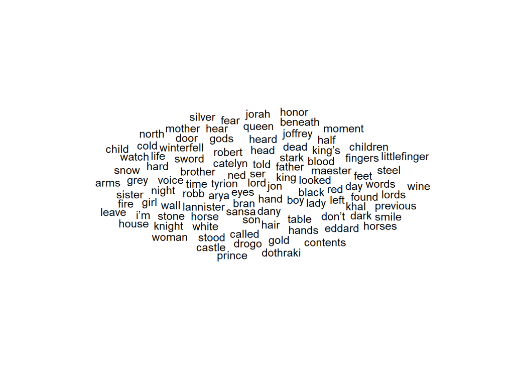

```r
GOT_cloud <- ggplot(data = GOT_top100, aes(label = word)) +
  geom_text_wordcloud() +
  theme_minimal()

GOT_cloud
```

I then customize it a bit to make the word cloud more effective:

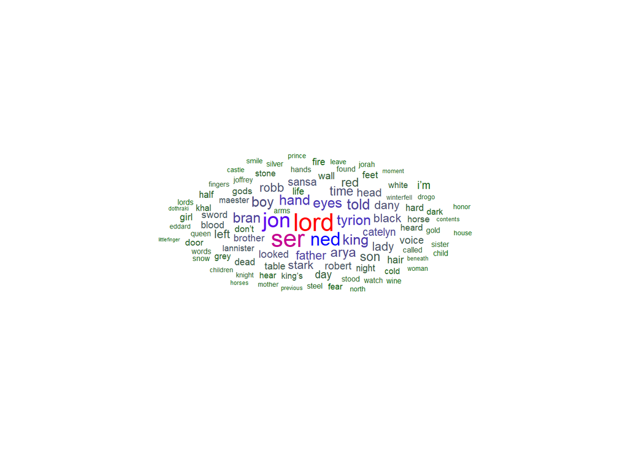

```r
ggplot(data = GOT_top100, aes(label = word, size = n)) +
  geom_text_wordcloud_area(aes(color = n), shape = "triangle") +
  scale_size_area(max_size = 12) +
  scale_color_gradientn(colors = c("darkgreen","blue","red")) +
  theme_minimal()
```

I have now made an easily readable word cloud showing the most frequent words like Lord, Ser, Jon, Ned and so on. Now to the sentiment analysis. To get rid of titles and names we could make a list of our own stopwords. But for now We will continue with the sentiment analysis.

### Sentiment analysis

Game of Thrones is grim-dark fantasy which often has a tone, style, or setting that is particularly bleak, amoral, and violent. I therefore expect that negative emotions will dominate the text rather than positive emotions.

In my sentiment analysis We will look at three general-purpose lexicons which are

- AFINN from Finn Årup Nielsen,
- bing from Bing Liu and collaborators, and
- nrc from Saif Mohammad and Peter Turney

“afinn”: Words ranked from -5 (very negative) to +5 (very positive)

```r
get_sentiments(lexicon = "afinn")
```

```
## # A tibble: 2,477 × 2
##    word       value
##    <chr>      <dbl>
##  1 abandon       -2
##  2 abandoned     -2
##  3 abandons      -2
##  4 abducted      -2
##  5 abduction     -2
##  6 abductions    -2
##  7 abhor         -3
##  8 abhorred      -3
##  9 abhorrent     -3
## 10 abhors        -3
## # ℹ 2,467 more rows
```

```r
# We look at the some of the positive words to see if it works:
afinn_pos <- get_sentiments("afinn") %>%
  filter(value %in% c(3,4,5))
afinn_pos
```

```
## # A tibble: 222 × 2
##    word         value
##    <chr>        <dbl>
##  1 admire           3
##  2 admired          3
##  3 admires          3
##  4 admiring         3
##  5 adorable         3
##  6 adore            3
##  7 adored           3
##  8 adores           3
##  9 affection        3
## 10 affectionate     3
## # ℹ 212 more rows
```

bing: binary, “positive” or “negative”

```r
get_sentiments(lexicon = "bing")
```

```
## # A tibble: 6,786 × 2
##    word        sentiment
##    <chr>       <chr>
##  1 2-faces     negative
##  2 abnormal    negative
##  3 abolish     negative
##  4 abominable  negative
##  5 abominably  negative
##  6 abominate   negative
##  7 abomination negative
##  8 abort       negative
##  9 aborted     negative
## 10 aborts      negative
## # ℹ 6,776 more rows
```

Now We will look at nrc:

```r
get_sentiments(lexicon = "nrc")
```

```
## # A tibble: 13,872 × 2
##    word        sentiment
##    <chr>       <chr>
##  1 abacus      trust
##  2 abandon     fear
##  3 abandon     negative
##  4 abandon     sadness
##  5 abandoned   anger
##  6 abandoned   fear
##  7 abandoned   negative
##  8 abandoned   sadness
##  9 abandonment anger
## 10 abandonment fear
## # ℹ 13,862 more rows
```

I will now do sentiment analysis on the GOT text data using afinn and nrc.

### Sentiment analysis with afinn:

First We bind words in `GOT_stop` to `afinn` lexicon:

```r
GOT_afinn <- GOT_stop %>%
  inner_join(get_sentiments("afinn"))
GOT_afinn
```

```
## # A tibble: 13,058 × 2
##    word  value
##    <chr> <dbl>
##  1 fire     -2
##  2 dead     -3
##  3 dead     -3
##  4 smile     2
##  5 dead     -3
##  6 dead     -3
##  7 dead     -3
##  8 dead     -3
##  9 dead     -3
## 10 drag     -1
## # ℹ 13,048 more rows
```

I then make a visualisation of how frequently each sentiment ranking occur in the pdf. This will give us an impression of the tone of the language.

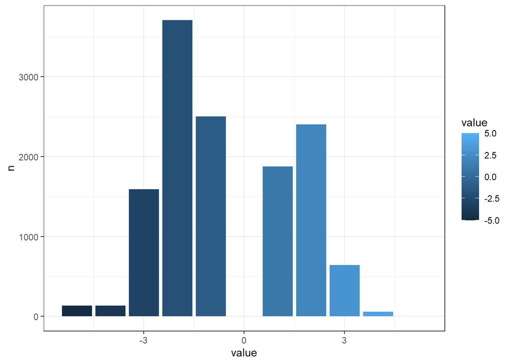

```r
GOT_afinn_hist <- GOT_afinn %>%
  count(value)

# Plot them:
ggplot(data = GOT_afinn_hist, aes(x = value, y = n)) +
  geom_col(aes(fill = value)) +
  theme_bw()
```

So we can see that there are more negative sentiment rankings in the pdf, a lot of them being of the value -2

I then investigate some of the words in a bit more depth:

```r
# We look at the words with the value 2
GOT_afinn2 <- GOT_afinn %>%
  filter(value == 2)

GOT_afinn2
```

```
## # A tibble: 2,405 × 2
##    word     value
##    <chr>    <dbl>
##  1 smile        2
##  2 fine         2
##  3 glory        2
##  4 hope         2
##  5 smiled       2
##  6 care         2
##  7 strength     2
##  8 peaceful     2
##  9 smile        2
## 10 smile        2
## # ℹ 2,395 more rows
```

```r
# We then check the unique 2-score words:
unique(GOT_afinn2$word)
```

```
##   [1] "smile"           "fine"            "glory"           "hope"
##   [5] "smiled"          "care"            "strength"        "peaceful"
##   [9] "honor"           "carefully"       "slick"           "top"
##  [13] "gained"          "comfort"         "sweet"           "courage"
##  [17] "daring"          "elegant"         "justice"         "heroes"
##  [21] "fair"            "strong"          "brave"           "solid"
##  [25] "proud"           "mercy"           "rescue"          "swift"
##  [29] "smiling"         "true"            "noble"           "saved"
##  [33] "gift"            "treasures"       "favorite"        "clean"
##  [37] "rich"            "fearless"        "fortunate"       "likes"
##  [41] "earnest"         "generous"        "chances"         "smiles"
##  [45] "hug"             "kiss"            "approved"        "fond"
##  [49] "honored"         "consent"         "peace"           "powerful"
##  [53] "worthy"          "humor"           "entertaining"    "save"
##  [57] "sincerely"       "festive"         "careful"         "stronger"
```

[output cut: 36 more lines]

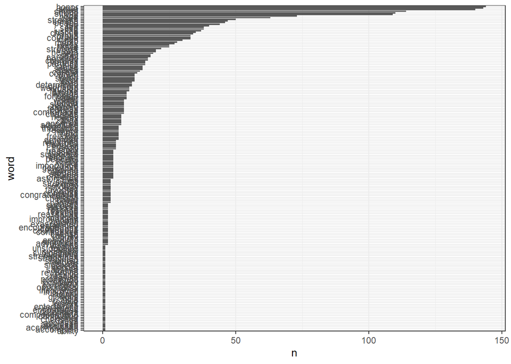

```r
# We count & plot them
GOT_afinn2_n <- GOT_afinn2 %>%
  count(word, sort = TRUE) %>%
  mutate(word = fct_reorder(factor(word), n))


ggplot(data = GOT_afinn2_n, aes(x = word, y = n)) +
  geom_col() +
  coord_flip() +
  theme(text = element_text(size = 12))+
  theme_bw()
```

```r
ggsave(here("figures","GOT_afinn2_n.png"),
       height = 17,
       width = 5)

# We can see the word honor topping the list of 2-score words. First of all tells us that honor is a significant theme in the book, and without the proper context it can be a bit hard to sat whether the book has a positive or negative approach to honor
```

I summarize the Afinn sentiment analysis and find out what the mean and median score of the sentiment score

```r
GOT_summary <- GOT_afinn %>%
  summarize(
    mean_score = mean(value),
    median_score = median(value)
  )
GOT_summary
```

```
## # A tibble: 1 × 2
##   mean_score median_score
##        <dbl>        <dbl>
## 1     -0.542           -1
```

The mean and median indicate slightly negative overall sentiments based on the AFINN lexicon. Game of Thrones is considered a grim-dark fantasy book, so it makes sense for the sentiments to be slightly negative.

### We then use the NRC lexicon for sentiment analysis

We can use the NRC lexicon to start “binning” text by the feelings they’re typically associated with. As above, we’ll use inner_join() to combine the GOT non-stopword text with the nrc lexicon:

```r
GOT_nrc <- GOT_stop %>%
  inner_join(get_sentiments("nrc"))

GOT_nrc
```

```
## # A tibble: 63,312 × 2
##    word     sentiment
##    <chr>    <chr>
##  1 fire     fear
##  2 prologue anticipation
##  3 stark    negative
##  4 stark    trust
##  5 prologue anticipation
##  6 start    anticipation
##  7 grow     anticipation
##  8 grow     joy
##  9 grow     positive
## 10 grow     trust
## # ℹ 63,302 more rows
```

That will exclude some of the words in the text. We check which are excluded using `anti_join()`:

```r
GOT_exclude <- GOT_stop %>%
  anti_join(get_sentiments("nrc"))

# View(GOT_exclude)

GOT_exclude
```

```
## # A tibble: 90,465 × 1
##    word
##    <chr>
##  1 game
##  2 thrones
##  3 book
##  4 song
##  5 ice
##  6 george
##  7 r.r
##  8 martin
##  9 contents
## 10 maps
## # ℹ 90,455 more rows
```

```r
# Count to find the most excluded:
GOT_exclude_n <- GOT_exclude %>%
  count(word, sort = TRUE)

GOT_exclude_n
```

```
## # A tibble: 9,041 × 2
##    word        n
##    <chr>   <int>
##  1 ser      1023
##  2 jon       787
##  3 ned       743
##  4 tyrion    591
##  5 eyes      567
##  6 hand      567
##  7 told      504
##  8 catelyn   481
##  9 arya      451
## 10 boy       422
## # ℹ 9,031 more rows
```

```r
head(GOT_exclude_n)
```

```
## # A tibble: 6 × 2
##   word       n
##   <chr>  <int>
## 1 ser     1023
## 2 jon      787
## 3 ned      743
## 4 tyrion   591
## 5 eyes     567
## 6 hand     567
```

One of the words which are excluded by NRC is ‘dead’, a word with a very negative sentiment. It’s noteworthy that NRC doesn’t include this, because it makes NRC weaker as a tool for sentiment analysis.

Now We find counts of NRC sentiments in GOT and plot them:

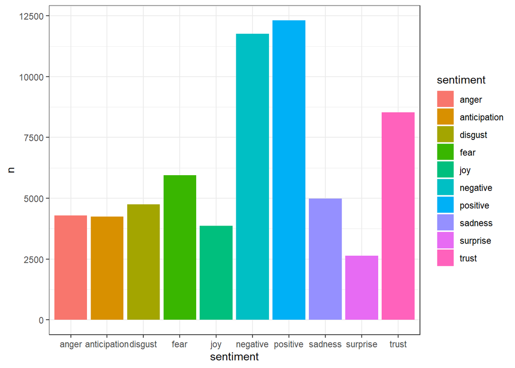

```r
GOT_nrc_n <- GOT_nrc %>%
  count(sentiment, sort = TRUE)

# And plot them:

ggplot(data = GOT_nrc_n, aes(x = sentiment, y = n)) +
  geom_col(aes(fill = sentiment))+
  theme_bw()
```

I then make a visualisation of the counts by sentiment **and** word.

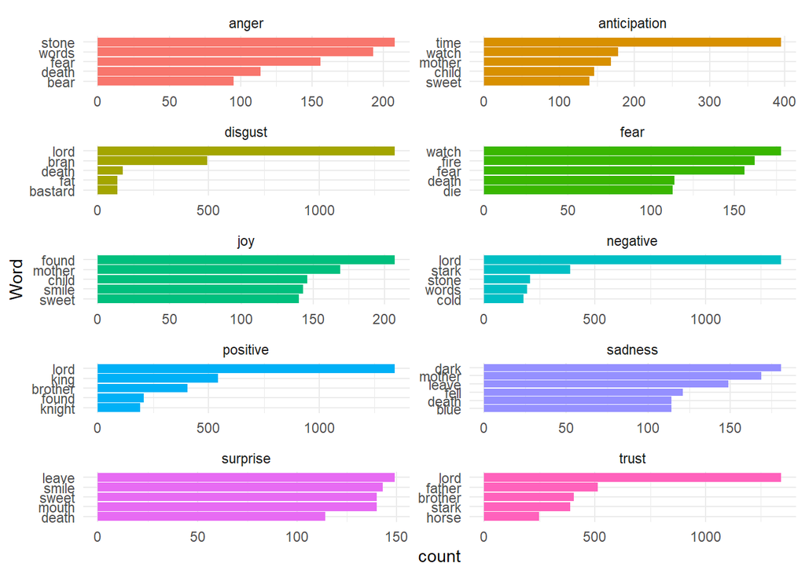

```r
GOT_nrc_n5 <- GOT_nrc %>%
  count(word,sentiment, sort = TRUE) %>%
  group_by(sentiment) %>%
  top_n(5) %>%
  ungroup()

GOT_nrc_gg <- ggplot(data = GOT_nrc_n5, aes(x = reorder(word,n), y = n, fill = sentiment)) +
  geom_col(show.legend = FALSE) +
  facet_wrap(~sentiment, ncol = 2, scales = "free") +
  coord_flip() +
  theme_minimal() +
  labs(x = "Word", y = "count")

# Show it
GOT_nrc_gg
```

```r
# Save it
ggsave(plot = GOT_nrc_gg,
       here("figures","GOT_nrc_sentiment.png"),
       height = 8,
       width = 5)
```

Here we can see weird examples showing up like ‘stone’ and ‘words’ being associated with anger and ‘mother’ being associated with anticipation. A name like Bran is also associated with disgust because NRC sees it as a normal word and not a name. All these things would have to be kept in mind and edited to make sense for the given text.